# United Airlines Departure Delays

2025-10-25

# United Airlines Departure Delays Project

This project will examine the relationship between United Airlines departure delays and time of day, time of year, temperature, wind speed, precipitation, and visibility.

## Introduction

We set out to understand when and under what conditions United flights tend to depart late from New York–area airports, using the public nycflights13 dataset for 2013, imported in our RStudio environment. We look at time of day, time of year, and common weather factors: temperature, wind speed, precipitation, and visibility. We summarize what the data shows. To check whether visible patterns are likely more than chance, we use permutation tests, a resampling method that shuffles labels and compares the observed result to what we’d expect if there were no real relationship.

###### Install libraries

```r
library(tidyverse)
library(nycflights13)
```

## Prepare the Data

###### Inspect the data

```r
glimpse(flights)
```

```
## Rows: 336,776
## Columns: 19
## $ year           <int> 2013, 2013, 2013, 2013, 2013, 2013, 2013, 2013, 2013, 2…
## $ month          <int> 1, 1, 1, 1, 1, 1, 1, 1, 1, 1, 1, 1, 1, 1, 1, 1, 1, 1, 1…
## $ day            <int> 1, 1, 1, 1, 1, 1, 1, 1, 1, 1, 1, 1, 1, 1, 1, 1, 1, 1, 1…
## $ dep_time       <int> 517, 533, 542, 544, 554, 554, 555, 557, 557, 558, 558, …
## $ sched_dep_time <int> 515, 529, 540, 545, 600, 558, 600, 600, 600, 600, 600, …
## $ dep_delay      <dbl> 2, 4, 2, -1, -6, -4, -5, -3, -3, -2, -2, -2, -2, -2, -1…
## $ arr_time       <int> 830, 850, 923, 1004, 812, 740, 913, 709, 838, 753, 849,…
## $ sched_arr_time <int> 819, 830, 850, 1022, 837, 728, 854, 723, 846, 745, 851,…
## $ arr_delay      <dbl> 11, 20, 33, -18, -25, 12, 19, -14, -8, 8, -2, -3, 7, -1…
## $ carrier        <chr> "UA", "UA", "AA", "B6", "DL", "UA", "B6", "EV", "B6", "…
## $ flight         <int> 1545, 1714, 1141, 725, 461, 1696, 507, 5708, 79, 301, 4…
## $ tailnum        <chr> "N14228", "N24211", "N619AA", "N804JB", "N668DN", "N394…
## $ origin         <chr> "EWR", "LGA", "JFK", "JFK", "LGA", "EWR", "EWR", "LGA",…
## $ dest           <chr> "IAH", "IAH", "MIA", "BQN", "ATL", "ORD", "FLL", "IAD",…
## $ air_time       <dbl> 227, 227, 160, 183, 116, 150, 158, 53, 140, 138, 149, 1…
## $ distance       <dbl> 1400, 1416, 1089, 1576, 762, 719, 1065, 229, 944, 733, …
## $ hour           <dbl> 5, 5, 5, 5, 6, 5, 6, 6, 6, 6, 6, 6, 6, 6, 6, 5, 6, 6, 6…
## $ minute         <dbl> 15, 29, 40, 45, 0, 58, 0, 0, 0, 0, 0, 0, 0, 0, 0, 59, 0…
## $ time_hour      <dttm> 2013-01-01 05:00:00, 2013-01-01 05:00:00, 2013-01-01 0…
```

```r
glimpse(weather)
```

```
## Rows: 26,115
## Columns: 15
## $ origin     <chr> "EWR", "EWR", "EWR", "EWR", "EWR", "EWR", "EWR", "EWR", "EW…
## $ year       <int> 2013, 2013, 2013, 2013, 2013, 2013, 2013, 2013, 2013, 2013,…
## $ month      <int> 1, 1, 1, 1, 1, 1, 1, 1, 1, 1, 1, 1, 1, 1, 1, 1, 1, 1, 1, 1,…
## $ day        <int> 1, 1, 1, 1, 1, 1, 1, 1, 1, 1, 1, 1, 1, 1, 1, 1, 1, 1, 1, 1,…
## $ hour       <int> 1, 2, 3, 4, 5, 6, 7, 8, 9, 10, 11, 13, 14, 15, 16, 17, 18, …
## $ temp       <dbl> 39.02, 39.02, 39.02, 39.92, 39.02, 37.94, 39.02, 39.92, 39.…
## $ dewp       <dbl> 26.06, 26.96, 28.04, 28.04, 28.04, 28.04, 28.04, 28.04, 28.…
## $ humid      <dbl> 59.37, 61.63, 64.43, 62.21, 64.43, 67.21, 64.43, 62.21, 62.…
## $ wind_dir   <dbl> 270, 250, 240, 250, 260, 240, 240, 250, 260, 260, 260, 330,…
## $ wind_speed <dbl> 10.35702, 8.05546, 11.50780, 12.65858, 12.65858, 11.50780, …
## $ wind_gust  <dbl> NA, NA, NA, NA, NA, NA, NA, NA, NA, NA, NA, NA, NA, NA, 20.…
## $ precip     <dbl> 0, 0, 0, 0, 0, 0, 0, 0, 0, 0, 0, 0, 0, 0, 0, 0, 0, 0, 0, 0,…
## $ pressure   <dbl> 1012.0, 1012.3, 1012.5, 1012.2, 1011.9, 1012.4, 1012.2, 101…
## $ visib      <dbl> 10, 10, 10, 10, 10, 10, 10, 10, 10, 10, 10, 10, 10, 10, 10,…
## $ time_hour  <dttm> 2013-01-01 01:00:00, 2013-01-01 02:00:00, 2013-01-01 03:00…
```

###### Keep only the relevant United Airlines flights

```r
flights_UA <- flights %>%
  filter(carrier == 'UA') %>%
  filter(!is.na(dep_delay))
```

###### Create the “late” and “very_late” columns

```r
flights_UA <- flights_UA %>%
  mutate(
    late = dep_delay > 0,
    very_late = dep_delay > 30
    )
glimpse(flights_UA)
```

```
## Rows: 57,979
## Columns: 21
## $ year           <int> 2013, 2013, 2013, 2013, 2013, 2013, 2013, 2013, 2013, 2…
## $ month          <int> 1, 1, 1, 1, 1, 1, 1, 1, 1, 1, 1, 1, 1, 1, 1, 1, 1, 1, 1…
## $ day            <int> 1, 1, 1, 1, 1, 1, 1, 1, 1, 1, 1, 1, 1, 1, 1, 1, 1, 1, 1…
## $ dep_time       <int> 517, 533, 554, 558, 558, 559, 607, 611, 623, 628, 643, …
## $ sched_dep_time <int> 515, 529, 558, 600, 600, 600, 607, 600, 627, 630, 646, …
## $ dep_delay      <dbl> 2, 4, -4, -2, -2, -1, 0, 11, -4, -2, -3, 8, 1, 1, -4, -…
## $ arr_time       <int> 830, 850, 740, 924, 923, 854, 858, 945, 933, 1016, 922,…
## $ sched_arr_time <int> 819, 830, 728, 917, 937, 902, 915, 931, 932, 947, 940, …
## $ arr_delay      <dbl> 11, 20, 12, 7, -14, -8, -17, 14, 1, 29, -18, -9, -6, -7…
## $ carrier        <chr> "UA", "UA", "UA", "UA", "UA", "UA", "UA", "UA", "UA", "…
## $ flight         <int> 1545, 1714, 1696, 194, 1124, 1187, 1077, 303, 496, 1665…
## $ tailnum        <chr> "N14228", "N24211", "N39463", "N29129", "N53441", "N765…
## $ origin         <chr> "EWR", "LGA", "EWR", "JFK", "EWR", "EWR", "EWR", "JFK",…
## $ dest           <chr> "IAH", "IAH", "ORD", "LAX", "SFO", "LAS", "MIA", "SFO",…
## $ air_time       <dbl> 227, 227, 150, 345, 361, 337, 157, 366, 229, 366, 146, …
## $ distance       <dbl> 1400, 1416, 719, 2475, 2565, 2227, 1085, 2586, 1416, 24…
## $ hour           <dbl> 5, 5, 5, 6, 6, 6, 6, 6, 6, 6, 6, 6, 6, 6, 7, 7, 7, 7, 7…
## $ minute         <dbl> 15, 29, 58, 0, 0, 0, 7, 0, 27, 30, 46, 36, 45, 45, 0, 0…
## $ time_hour      <dttm> 2013-01-01 05:00:00, 2013-01-01 05:00:00, 2013-01-01 0…
## $ late           <lgl> TRUE, TRUE, FALSE, FALSE, FALSE, FALSE, FALSE, TRUE, FA…
## $ very_late      <lgl> FALSE, FALSE, FALSE, FALSE, FALSE, FALSE, FALSE, FALSE,…
```

###### Join the flight data and the weather data.

Use a left join so that the weather data is applied to each flight

```r
flights_weather <- flights_UA %>%
  left_join(weather, by = c('origin', 'time_hour', 'year', 'month', 'day', 'hour'))
glimpse(flights_weather)
```

```
## Rows: 57,979
## Columns: 30
## $ year           <int> 2013, 2013, 2013, 2013, 2013, 2013, 2013, 2013, 2013, 2…
## $ month          <int> 1, 1, 1, 1, 1, 1, 1, 1, 1, 1, 1, 1, 1, 1, 1, 1, 1, 1, 1…
## $ day            <int> 1, 1, 1, 1, 1, 1, 1, 1, 1, 1, 1, 1, 1, 1, 1, 1, 1, 1, 1…
## $ dep_time       <int> 517, 533, 554, 558, 558, 559, 607, 611, 623, 628, 643, …
## $ sched_dep_time <int> 515, 529, 558, 600, 600, 600, 607, 600, 627, 630, 646, …
## $ dep_delay      <dbl> 2, 4, -4, -2, -2, -1, 0, 11, -4, -2, -3, 8, 1, 1, -4, -…
## $ arr_time       <int> 830, 850, 740, 924, 923, 854, 858, 945, 933, 1016, 922,…
## $ sched_arr_time <int> 819, 830, 728, 917, 937, 902, 915, 931, 932, 947, 940, …
## $ arr_delay      <dbl> 11, 20, 12, 7, -14, -8, -17, 14, 1, 29, -18, -9, -6, -7…
## $ carrier        <chr> "UA", "UA", "UA", "UA", "UA", "UA", "UA", "UA", "UA", "…
## $ flight         <int> 1545, 1714, 1696, 194, 1124, 1187, 1077, 303, 496, 1665…
## $ tailnum        <chr> "N14228", "N24211", "N39463", "N29129", "N53441", "N765…
## $ origin         <chr> "EWR", "LGA", "EWR", "JFK", "EWR", "EWR", "EWR", "JFK",…
```

[output cut: 17 more lines]

###### Create a “season” column.

First check how many are null values in the “month” column.

```r
sum(is.na(flights_weather$month))
```

```
## [1] 0
```

Now create the “season” column. Use this definition: summer consists of June, July, and August; fall consists of September, October, and November; winter consists of December, January, and February; spring consists of March, April, and May.

```r
flights_weather <- flights_weather %>%
  mutate(season = case_when(
    month %in% c(12, 1, 2) ~ 'winter',
    month %in% c(3, 4, 5) ~ 'spring',
    month %in% c(6, 7, 8) ~ 'summer',
    month %in% c(9, 10, 11) ~ 'fall'
  ))
glimpse(flights_weather)
```

```
## Rows: 57,979
## Columns: 31
## $ year           <int> 2013, 2013, 2013, 2013, 2013, 2013, 2013, 2013, 2013, 2…
## $ month          <int> 1, 1, 1, 1, 1, 1, 1, 1, 1, 1, 1, 1, 1, 1, 1, 1, 1, 1, 1…
## $ day            <int> 1, 1, 1, 1, 1, 1, 1, 1, 1, 1, 1, 1, 1, 1, 1, 1, 1, 1, 1…
## $ dep_time       <int> 517, 533, 554, 558, 558, 559, 607, 611, 623, 628, 643, …
## $ sched_dep_time <int> 515, 529, 558, 600, 600, 600, 607, 600, 627, 630, 646, …
## $ dep_delay      <dbl> 2, 4, -4, -2, -2, -1, 0, 11, -4, -2, -3, 8, 1, 1, -4, -…
## $ arr_time       <int> 830, 850, 740, 924, 923, 854, 858, 945, 933, 1016, 922,…
## $ sched_arr_time <int> 819, 830, 728, 917, 937, 902, 915, 931, 932, 947, 940, …
## $ arr_delay      <dbl> 11, 20, 12, 7, -14, -8, -17, 14, 1, 29, -18, -9, -6, -7…
## $ carrier        <chr> "UA", "UA", "UA", "UA", "UA", "UA", "UA", "UA", "UA", "…
## $ flight         <int> 1545, 1714, 1696, 194, 1124, 1187, 1077, 303, 496, 1665…
## $ tailnum        <chr> "N14228", "N24211", "N39463", "N29129", "N53441", "N765…
## $ origin         <chr> "EWR", "LGA", "EWR", "JFK", "EWR", "EWR", "EWR", "JFK",…
```

[output cut: 18 more lines]

###### Create a time_of_day column.

What times do flights operate?

```r
unique(flights_weather$hour)
```

```
##  [1]  5  6  7  8  9 10 11 12 13 14 15 16 17 18 19 20 21 23 22
```

How many null values are there in the hour column?

```r
sum(is.na(flights_weather$hour))
```

```
## [1] 0
```

```r
flights_weather <- flights_weather %>%
  mutate(time_of_day = case_when(
    hour %in% c(5, 6, 7) ~ 'early',
    hour %in% c(8, 9, 10) ~ 'morning',
    hour %in% c(11, 12, 13) ~ 'mid_day',
    hour %in% c(14, 15, 16) ~ 'afternoon',
    hour %in% c(17, 18, 19) ~ 'evening',
    hour %in% c(20, 21, 22, 23) ~ 'night'
  ))
glimpse(flights_weather)
```

```
## Rows: 57,979
## Columns: 32
## $ year           <int> 2013, 2013, 2013, 2013, 2013, 2013, 2013, 2013, 2013, 2…
## $ month          <int> 1, 1, 1, 1, 1, 1, 1, 1, 1, 1, 1, 1, 1, 1, 1, 1, 1, 1, 1…
## $ day            <int> 1, 1, 1, 1, 1, 1, 1, 1, 1, 1, 1, 1, 1, 1, 1, 1, 1, 1, 1…
## $ dep_time       <int> 517, 533, 554, 558, 558, 559, 607, 611, 623, 628, 643, …
## $ sched_dep_time <int> 515, 529, 558, 600, 600, 600, 607, 600, 627, 630, 646, …
## $ dep_delay      <dbl> 2, 4, -4, -2, -2, -1, 0, 11, -4, -2, -3, 8, 1, 1, -4, -…
## $ arr_time       <int> 830, 850, 740, 924, 923, 854, 858, 945, 933, 1016, 922,…
## $ sched_arr_time <int> 819, 830, 728, 917, 937, 902, 915, 931, 932, 947, 940, …
## $ arr_delay      <dbl> 11, 20, 12, 7, -14, -8, -17, 14, 1, 29, -18, -9, -6, -7…
## $ carrier        <chr> "UA", "UA", "UA", "UA", "UA", "UA", "UA", "UA", "UA", "…
## $ flight         <int> 1545, 1714, 1696, 194, 1124, 1187, 1077, 303, 496, 1665…
## $ tailnum        <chr> "N14228", "N24211", "N39463", "N29129", "N53441", "N765…
## $ origin         <chr> "EWR", "LGA", "EWR", "JFK", "EWR", "EWR", "EWR", "JFK",…
```

[output cut: 19 more lines]

Convert the time_of_day column to a factor with a specific order for consistent plotting and analysis

```r
flights_weather <- flights_weather %>%
  mutate(time_of_day = fct_relevel(time_of_day,
                                 'early',
                                 'morning',
                                 'mid_day',
                                 'afternoon',
                                 'evening',
                                 'night'))
count(flights_weather, time_of_day)
```

```
## # A tibble: 6 × 2
##   time_of_day     n
##   <fct>       <int>
## 1 early       10579
## 2 morning     10518
## 3 mid_day      8997
## 4 afternoon   11247
## 5 evening     11564
## 6 night        5074
```

###### Create Visibility Categories

What is in the visibility column?

```r
unique(flights_weather$visib)
```

```
##  [1] 10.00    NA  9.00  6.00  4.00  8.00  7.00  5.00  3.00  2.50  1.00  2.00
## [13]  0.25  0.50  0.12  1.50  0.00  0.75  0.06  1.75  1.25
```

How many NA values are there in the visibility column?

```r
sum(is.na(flights_weather$visib))
```

```
## [1] 293
```

Keep the rows that have visibility values

```r
flights_weather <- flights_weather %>%
  filter(!is.na(visib))
```

Create visibility categories based on common visibility cutoffs in aviation. IMC (Instrument Meteorological Conditions): below 3, call this ‘poor’. MVFR (Marginal Visual Flight Rules): 3 to 5, call this ‘fair’. VFR (Visual Flight Rules): above 5, call this ‘good’.

```r
flights_weather <- flights_weather %>%
  mutate(visib_cat = case_when(
    visib < 3 ~ 'poor',
    visib >=3 & visib <= 5 ~ 'fair',
    visib > 5 ~ 'good'
  ))
glimpse(flights_weather)
```

```
## Rows: 57,686
## Columns: 33
## $ year           <int> 2013, 2013, 2013, 2013, 2013, 2013, 2013, 2013, 2013, 2…
## $ month          <int> 1, 1, 1, 1, 1, 1, 1, 1, 1, 1, 1, 1, 1, 1, 1, 1, 1, 1, 1…
## $ day            <int> 1, 1, 1, 1, 1, 1, 1, 1, 1, 1, 1, 1, 1, 1, 1, 1, 1, 1, 1…
## $ dep_time       <int> 517, 533, 554, 558, 558, 559, 607, 611, 623, 628, 643, …
## $ sched_dep_time <int> 515, 529, 558, 600, 600, 600, 607, 600, 627, 630, 646, …
## $ dep_delay      <dbl> 2, 4, -4, -2, -2, -1, 0, 11, -4, -2, -3, 8, 1, 1, -4, -…
## $ arr_time       <int> 830, 850, 740, 924, 923, 854, 858, 945, 933, 1016, 922,…
## $ sched_arr_time <int> 819, 830, 728, 917, 937, 902, 915, 931, 932, 947, 940, …
## $ arr_delay      <dbl> 11, 20, 12, 7, -14, -8, -17, 14, 1, 29, -18, -9, -6, -7…
## $ carrier        <chr> "UA", "UA", "UA", "UA", "UA", "UA", "UA", "UA", "UA", "…
## $ flight         <int> 1545, 1714, 1696, 194, 1124, 1187, 1077, 303, 496, 1665…
## $ tailnum        <chr> "N14228", "N24211", "N39463", "N29129", "N53441", "N765…
## $ origin         <chr> "EWR", "LGA", "EWR", "JFK", "EWR", "EWR", "EWR", "JFK",…
```

[output cut: 20 more lines]

Convert the visibility category column to a factor with a specific order for consistent plotting and analysis

```r
flights_weather <- flights_weather %>%
  mutate(visib_cat = fct_relevel(visib_cat,
                                 'poor',
                                 'fair',
                                 'good'))
count(flights_weather, visib_cat)
```

```
## # A tibble: 3 × 2
##   visib_cat     n
##   <fct>     <int>
## 1 poor       2079
## 2 fair       2049
## 3 good      53558
```

###### Create a column for whether or not there is precipitation.

```r
flights_weather <- flights_weather %>%
  mutate(precip_binary = precip > 0.00)
count(flights_weather, precip_binary)
```

```
## # A tibble: 2 × 2
##   precip_binary     n
##   <lgl>         <int>
## 1 FALSE         53645
## 2 TRUE           4041
```

###### Create quantile bins for temperature.

```r
sum(is.na(flights_weather$temp))
```

```
## [1] 7
```

Remove rows with NA in the temperature column.

```r
flights_weather <- flights_weather %>%
  filter(!is.na(temp))
```

Calculate the quantiles

```r
temp_quantiles <- quantile(flights_weather$temp, probs = seq(0, 1, 0.25))
```

Create a new column

```r
flights_weather$temp_q <- cut(flights_weather$temp,
                              breaks = temp_quantiles,
                              include.lowest = TRUE,
                              right = FALSE)

# Check the distribution of the new bins
table(flights_weather$temp_q)
```

```
##
## [10.9,42.1) [42.1,57.9)   [57.9,73)    [73,100]
##       13903       14714       14062       15000
```

###### Create quantile bins for wind speed.

```r
sum(is.na(flights_weather$wind_speed))
```

```
## [1] 17
```

Remove rows with NA in the wind speed column.

```r
flights_weather <- flights_weather %>%
  filter(!is.na(wind_speed))
```

Calculate the quantiles

```r
wind_speed_quantiles <- quantile(flights_weather$wind_speed, probs = seq(0, 1, 0.25))
```

Create a new column

```r
flights_weather$wind_speed_q <- cut(flights_weather$wind_speed,
                              breaks = wind_speed_quantiles,
                              include.lowest = TRUE,
                              right = FALSE)

# Check the distribution of the new bins
table(flights_weather$wind_speed_q)
```

```
##
##     [0,6.9)  [6.9,9.21) [9.21,13.8) [13.8,42.6]
##       13537       10153       18634       15338
```

###### Create a column for whether or not there are wind gusts.

I think that NA means there weren’t wind gusts. Check how many NA values in the wind gust column.

```r
sum(is.na(flights_weather$wind_gust))
```

```
## [1] 43094
```

Create a wind gust binary column.

```r
flights_weather <- flights_weather %>%
  mutate(wind_gust_binary = !is.na(wind_gust))
count(flights_weather, wind_gust_binary)
```

```
## # A tibble: 2 × 2
##   wind_gust_binary     n
##   <lgl>            <int>
## 1 FALSE            43094
## 2 TRUE             14568
```

Create a summary table.

```r
summary(flights_weather)
```

```
##       year          month             day           dep_time    sched_dep_time
##  Min.   :2013   Min.   : 1.000   Min.   : 1.00   Min.   :   1   Min.   : 500
##  1st Qu.:2013   1st Qu.: 4.000   1st Qu.: 8.00   1st Qu.: 855   1st Qu.: 855
##  Median :2013   Median : 7.000   Median :16.00   Median :1353   Median :1343
##  Mean   :2013   Mean   : 6.555   Mean   :15.68   Mean   :1327   Mean   :1311
##  3rd Qu.:2013   3rd Qu.:10.000   3rd Qu.:23.00   3rd Qu.:1732   3rd Qu.:1721
##  Max.   :2013   Max.   :12.000   Max.   :31.00   Max.   :2358   Max.   :2345
##
##    dep_delay         arr_time    sched_arr_time   arr_delay
##  Min.   :-20.00   Min.   :   1   Min.   :   1   Min.   :-75.000
##  1st Qu.: -4.00   1st Qu.:1112   1st Qu.:1136   1st Qu.:-19.000
##  Median :  0.00   Median :1547   Median :1607   Median : -6.000
##  Mean   : 12.09   Mean   :1508   Mean   :1544   Mean   :  3.546
##  3rd Qu.: 11.00   3rd Qu.:1943   3rd Qu.:1949   3rd Qu.: 12.000
##  Max.   :483.00   Max.   :2359   Max.   :2359   Max.   :455.000
##                   NA's   :63                    NA's   :197
##    carrier              flight         tailnum             origin
##  Length:57662       Min.   :   1.0   Length:57662       Length:57662
##  Class :character   1st Qu.: 504.0   Class :character   Class :character
##  Mode  :character   Median :1053.0   Mode  :character   Mode  :character
##                     Mean   : 961.8
##                     3rd Qu.:1431.0
##                     Max.   :1744.0
##
##      dest              air_time        distance         hour
##  Length:57662       Min.   : 23.0   Min.   : 116   Min.   : 5.00
##  Class :character   1st Qu.:135.0   1st Qu.: 937   1st Qu.: 8.00
##  Mode  :character   Median :197.0   Median :1400   Median :13.00
##                     Mean   :211.8   Mean   :1532   Mean   :12.85
##                     3rd Qu.:313.0   3rd Qu.:2425   3rd Qu.:17.00
##                     Max.   :695.0   Max.   :4963   Max.   :23.00
##                     NA's   :197
##      minute        time_hour                      late         very_late
##  Min.   : 0.00   Min.   :2013-01-01 05:00:00   Mode :logical   Mode :logical
##  1st Qu.: 9.00   1st Qu.:2013-04-05 09:15:00   FALSE:30583     FALSE:50096
##  Median :29.00   Median :2013-07-03 09:00:00   TRUE :27079     TRUE :7566
##  Mean   :26.75   Mean   :2013-07-03 08:45:19
##  3rd Qu.:44.00   3rd Qu.:2013-10-01 13:00:00
##  Max.   :59.00   Max.   :2013-12-30 18:00:00
##
```

[output cut: 17 more lines]

```
##  Min.   : 0.000   Length:57662       early    :10521   poor: 2078
##  1st Qu.:10.000   Class :character   morning  :10471   fair: 2049
##  Median :10.000   Mode  :character   mid_day  : 8965   good:53535
##  Mean   : 9.267                      afternoon:11204
##  3rd Qu.:10.000                      evening  :11488
##  Max.   :10.000                      night    : 5013
##
##  precip_binary           temp_q           wind_speed_q   wind_gust_binary
##  Mode :logical   [10.9,42.1):13903   [0,6.9)    :13537   Mode :logical
##  FALSE:53628     [42.1,57.9):14702   [6.9,9.21) :10153   FALSE:43094
##  TRUE :4034      [57.9,73)  :14061   [9.21,13.8):18634   TRUE :14568
##                  [73,100]   :14996   [13.8,42.6]:15338
##
##
##
```

Output the clean .csv

```r
write_csv(flights_weather, 'flights_clean.csv')
```

###### Exploratory Data Analysis

Departure delay vs time of day and time of year

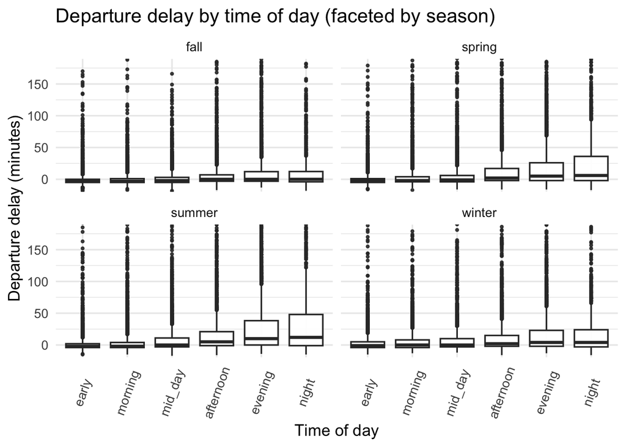

```r
ggplot(flights_weather, aes(x = time_of_day, y = dep_delay)) +
  geom_boxplot(outlier.size = 0.8, alpha = 0.9) +
  coord_cartesian(ylim = c(quantile(flights_weather$dep_delay, 0.01, na.rm=TRUE),
                           quantile(flights_weather$dep_delay, 0.99, na.rm=TRUE))) +
  facet_wrap(~season) +
  labs(title = "Departure delay by time of day (faceted by season)",
       x = "Time of day", y = "Departure delay (minutes)") +
  theme_minimal(base_size = 13) + theme(axis.text.x = element_text(angle = 70, vjust = 0.5))
```

######## Q1: Do flights departing in the evening and at night tends to get delayed longer than flights departing at earlier time?  
H~0: $\mu$~n - $\mu$~e = 0  
H~A: $\mu$~n - $\mu$~e $\ge$ 0

```r
evening_night = flights_weather$dep_delay[flights_weather$time_of_day == "evening" | flights_weather$time_of_day == "night"]
earlier = flights_weather$dep_delay[flights_weather$time_of_day != "evening" & flights_weather$time_of_day != "night"]

Time <- c(evening_night, earlier)

# Observed difference in means
observed <- mean(evening_night) - mean(earlier)
observed
```

```
## [1] 13.61528
```

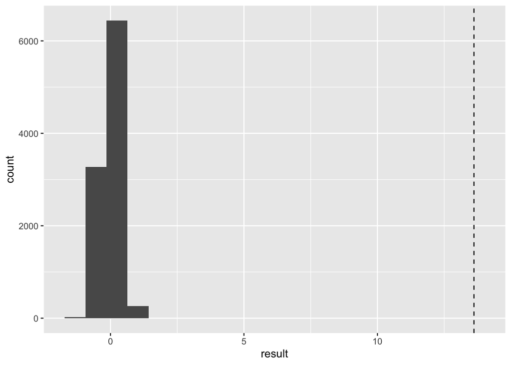

```r
# Get the sample sizes
n1 <- length(evening_night)
n_total <- length(Time)

# Permutation Test
N <- 10^4 - 1 # number of times to repeat this process
result <- numeric(N) # space to save the random differences

for (i in 1:N) {
  index <- sample(n_total, size = n1, replace = FALSE)
  result[i] <- mean(Time[index]) - mean(Time[-index])
}

# Plot histogram
ggplot() + geom_histogram(aes(result), bins = 20) +
geom_vline(xintercept = observed, linetype = "dashed")
```

```r
# P-value
p_value = (sum(result >= observed) + 1)/(N + 1)
p_value
```

```
## [1] 1e-04
```

```r
holiday = flights_weather$dep_delay[flights_weather$season == "winter" | flights_weather$season == "summer"]
other = flights_weather$dep_delay[flights_weather$season == "spring" & flights_weather$season != "fall"]

Time <- c(holiday, other)

# Observed difference in means
observed <- mean(holiday) - mean(other)
observed
```

```
## [1] 2.125382
```

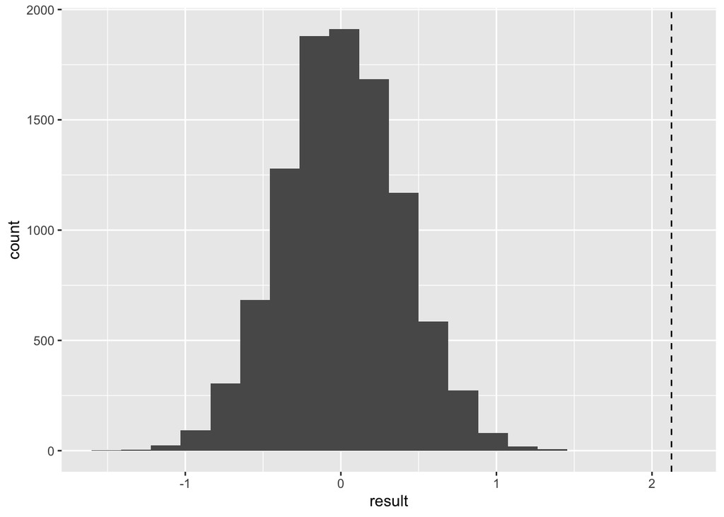

```r
# Get the sample sizes
n1 <- length(holiday)
n_total <- length(Time)

# Permutation Test
N <- 10^4 - 1 # number of times to repeat this process
result <- numeric(N) # space to save the random differences

for (i in 1:N) {
  index <- sample(n_total, size = n1, replace = FALSE)
  result[i] <- mean(Time[index]) - mean(Time[-index])
}

# Plot histogram
ggplot() + geom_histogram(aes(result), bins = 20) +
geom_vline(xintercept = observed, linetype = "dashed")
```

```r
# P-value
p_value = (sum(result >= observed) + 1)/(N + 1)
p_value
```

```
## [1] 1e-04
```

Departure delay vs Temperature

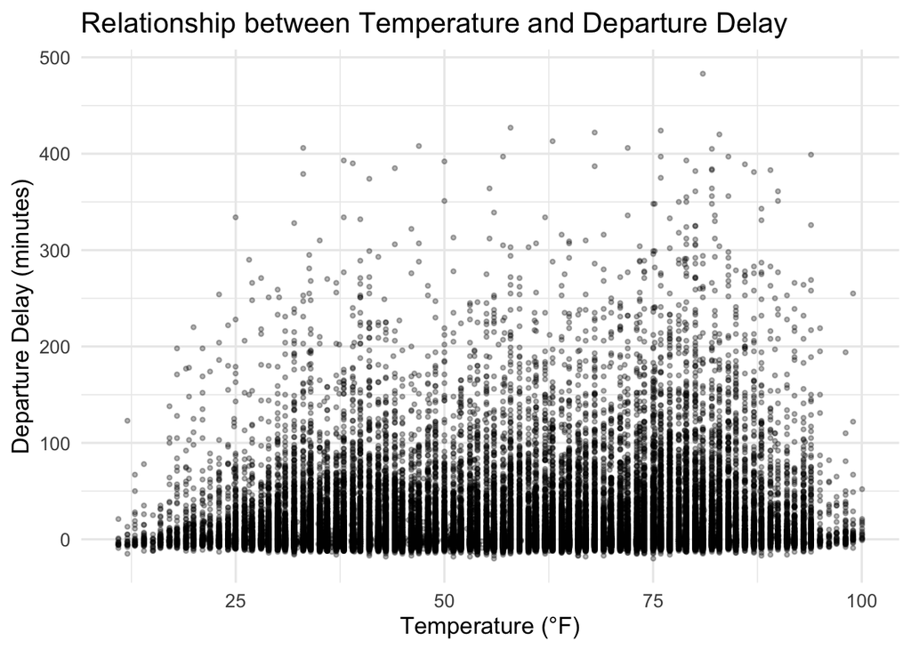

```r
ggplot(flights_weather, aes(x = temp, y = dep_delay)) +
  geom_point(alpha = 0.3, size = 0.8) +
  labs(
    title = "Relationship between Temperature and Departure Delay",
    x = "Temperature (°F)",
    y = "Departure Delay (minutes)"
  ) +
  theme_minimal(base_size = 13)
```

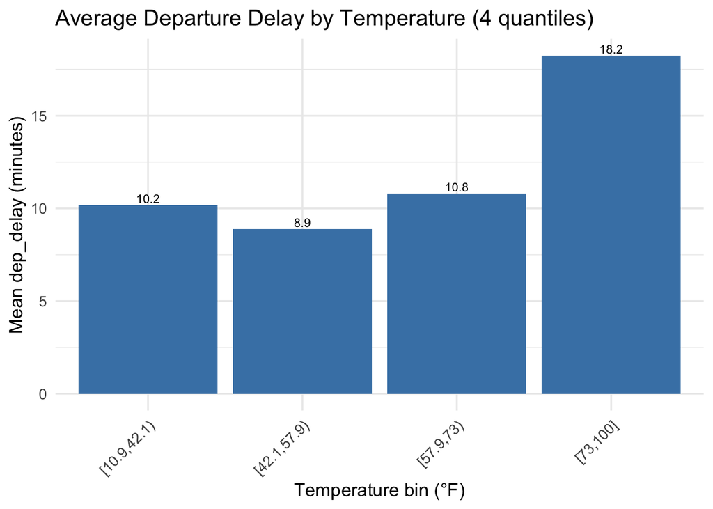

```r
flights_weather %>%
  group_by(temp_q) %>%
  summarize(mean_delay = mean(dep_delay, na.rm = TRUE),
            median_delay = median(dep_delay, na.rm = TRUE),
            n = n()) %>%
  ggplot(aes(x = temp_q, y = mean_delay)) +
  geom_col(fill = "steelblue") +
  geom_text(aes(label = round(mean_delay, 1)), vjust = -0.3, size = 3) +
  labs(
    title = "Average Departure Delay by Temperature (4 quantiles)",
    x = "Temperature bin (°F)",
    y = "Mean dep_delay (minutes)"
  ) +
  theme_minimal(base_size = 13) +
  theme(axis.text.x = element_text(angle = 45, hjust = 1))
```

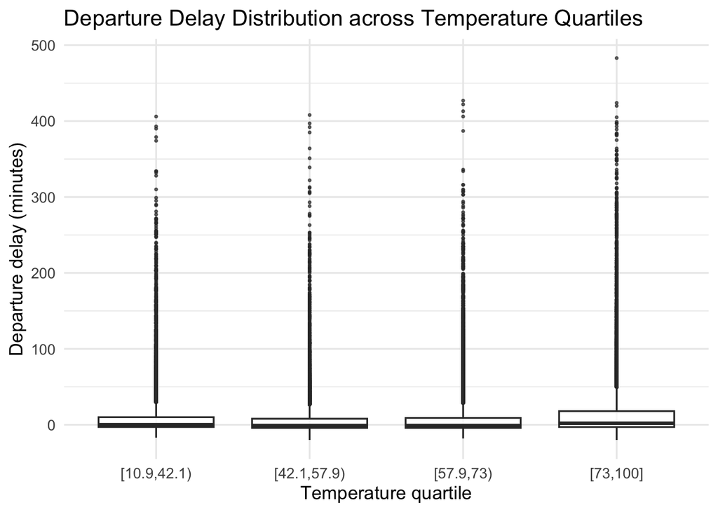

```r
ggplot(flights_weather, aes(x = factor(temp_q), y = dep_delay)) +
  geom_boxplot(outlier.size = 0.6, alpha = 0.7) +
  labs(
    title = "Departure Delay Distribution across Temperature Quartiles",
    x = "Temperature quartile",
    y = "Departure delay (minutes)"
  ) +
  theme_minimal(base_size = 13) +
  theme(legend.position = "none")
```

######## Q1: Do flights departing in warmer temperatures (4th quartile) tends to get delayed longer than flights departing in colder temperature (1st quartile)?  
H~0: $\mu$~W - $\mu$~C = 0  
H~A: $\mu$~W - $\mu$~C $\ge$ 0

```r
cold = flights_weather$dep_delay[flights_weather$temp >= 10.9 & flights_weather$temp < 42.1]
warm = flights_weather$dep_delay[flights_weather$temp >= 73 & flights_weather$temp <= 100]

Time <- c(warm, cold)

# Observed difference in means
observed <- mean(warm) - mean(cold)
observed
```

```
## [1] 8.10506
```

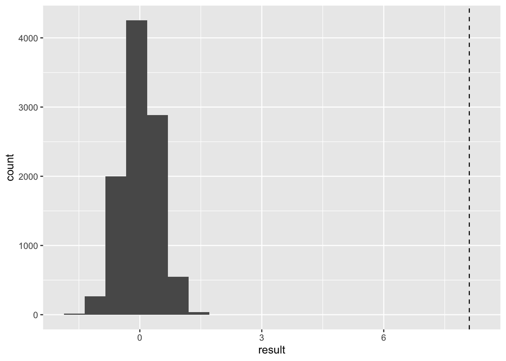

```r
# Get the sample sizes
n1 <- length(warm)
n_total <- length(Time)

# Permutation Test
N <- 10^4 - 1 # number of times to repeat this process
result <- numeric(N) # space to save the random differences

for (i in 1:N) {
  index <- sample(n_total, size = n1, replace = FALSE)
  result[i] <- mean(Time[index]) - mean(Time[-index])
}

# Plot histogram
ggplot() + geom_histogram(aes(result), bins = 20) +
geom_vline(xintercept = observed, linetype = "dashed")
```

```r
# P-value
p_value = (sum(result >= observed) + 1)/(N + 1)
p_value
```

```
## [1] 1e-04
```

Departure delay vs Wind Speed

[figure not shown]

```r
ggplot(flights_weather, aes(x = wind_speed, y = dep_delay)) +
  geom_point(alpha = 0.3, size = 0.8) +
  labs(
    title = "Relationship between Temperature and Departure Delay",
    x = "Wind Speed",
    y = "Departure Delay (minutes)"
  ) +
  theme_minimal(base_size = 13)
```

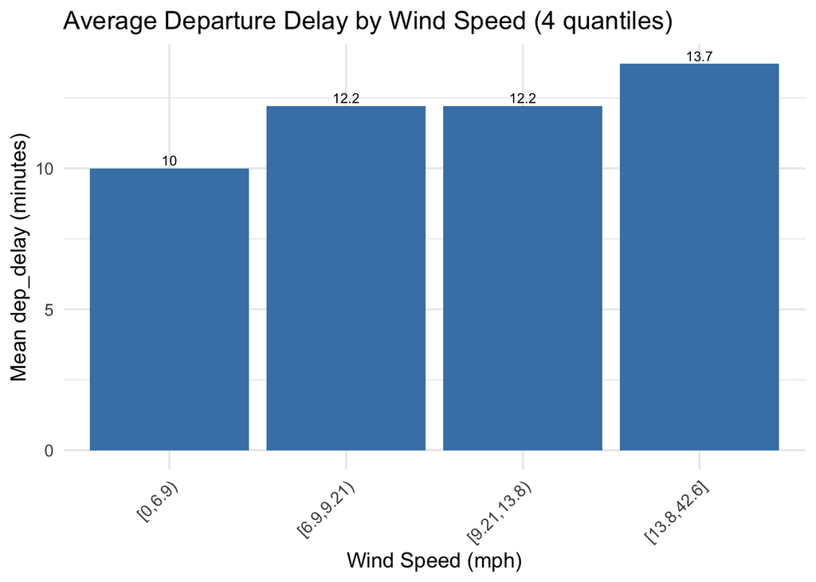

```r
flights_weather %>%
  group_by(wind_speed_q) %>%
  summarize(mean_delay = mean(dep_delay, na.rm = TRUE),
            median_delay = median(dep_delay, na.rm = TRUE),
            n = n()) %>%
  ggplot(aes(x = wind_speed_q, y = mean_delay)) +
  geom_col(fill = "steelblue") +
  geom_text(aes(label = round(mean_delay, 1)), vjust = -0.3, size = 3) +
  labs(
    title = "Average Departure Delay by Wind Speed (4 quantiles)",
    x = "Wind Speed (mph)",
    y = "Mean dep_delay (minutes)"
  ) +
  theme_minimal(base_size = 13) +
  theme(axis.text.x = element_text(angle = 45, hjust = 1))
```

######## Q1: Do flights departing in stronger wind (4th quartile) tends to get delayed longer than flights departing in milder wind (1st quartile)?  
H~0: $\mu$~F - $\mu$~S = 0  
H~A: $\mu$~F - $\mu$~S $\ge$ 0

```r
mild = flights_weather$dep_delay[flights_weather$wind_speed >= 0 & flights_weather$wind_speed < 6.9]
strong = flights_weather$dep_delay[flights_weather$wind_speed >= 13.8 & flights_weather$wind_speed <= 42.6]

Time <- c(strong, mild)

# Observed difference in means
observed <- mean(strong) - mean(mild)
observed
```

```
## [1] 3.715873
```

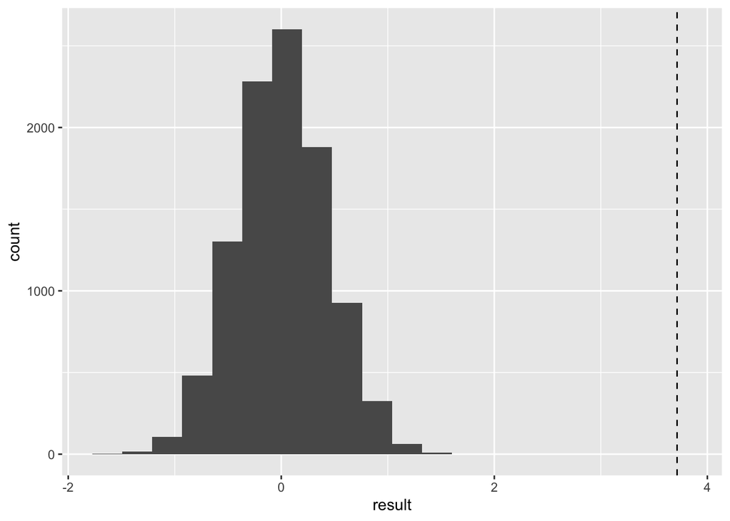

```r
# Get the sample sizes
n1 <- length(mild)
n_total <- length(Time)

# Permutation Test
N <- 10^4 - 1 # number of times to repeat this process
result <- numeric(N) # space to save the random differences

for (i in 1:N) {
  index <- sample(n_total, size = n1, replace = FALSE)
  result[i] <- mean(Time[index]) - mean(Time[-index])
}

# Plot histogram
ggplot() + geom_histogram(aes(result), bins = 20) +
geom_vline(xintercept = observed, linetype = "dashed")
```

```r
# P-value
p_value = (sum(result >= observed) + 1)/(N + 1)
p_value
```

```
## [1] 1e-04
```

Departure delay vs Precipitation

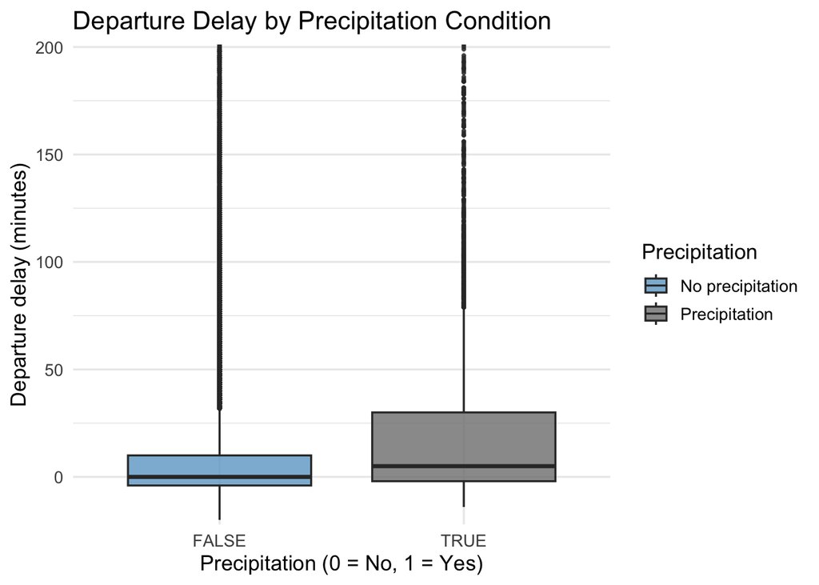

```r
ggplot(flights_weather, aes(x = precip_binary, y = dep_delay, fill = precip_binary)) +
  geom_boxplot(outlier.size = 0.7, alpha = 0.8) +
  scale_fill_manual(values = c("skyblue3", "gray50"),
                    labels = c("No precipitation", "Precipitation")) +
  labs(
    title = "Departure Delay by Precipitation Condition",
    x = "Precipitation (0 = No, 1 = Yes)",
    y = "Departure delay (minutes)",
    fill = "Precipitation"
  ) +
  coord_cartesian(ylim = quantile(flights$dep_delay, c(0.01, 0.99), na.rm = TRUE)) +
  theme_minimal(base_size = 13)
```

######## Q1: Do flights departing in precipitation tends to get delayed longer than flights departing in dry condition?  
H~0: $\mu$~W - $\mu$~D = 0  
H~A: $\mu$~W - $\mu$~D $\ge$ 0

```r
wet = flights_weather$dep_delay[flights_weather$precip_binary == TRUE]
dry = flights_weather$dep_delay[flights_weather$precip_binary == FALSE]

Time <- c(wet, dry)

# Observed difference in means
observed <- mean(wet) - mean(dry)
observed
```

```
## [1] 13.46498
```

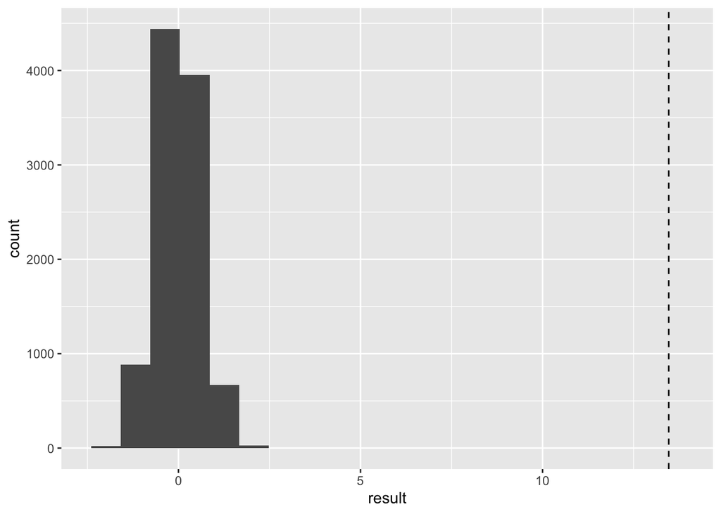

```r
# Get the sample sizes
n1 <- length(wet)
n_total <- length(Time)

# Permutation Test
N <- 10^4 - 1 # number of times to repeat this process
result <- numeric(N) # space to save the random differences

for (i in 1:N) {
  index <- sample(n_total, size = n1, replace = FALSE)
  result[i] <- mean(Time[index]) - mean(Time[-index])
}

# Plot histogram
ggplot() + geom_histogram(aes(result), bins = 20) +
geom_vline(xintercept = observed, linetype = "dashed")
```

```r
# P-value
p_value = (sum(result >= observed) + 1)/(N + 1)
p_value
```

```
## [1] 1e-04
```

Departure delay vs Visibility

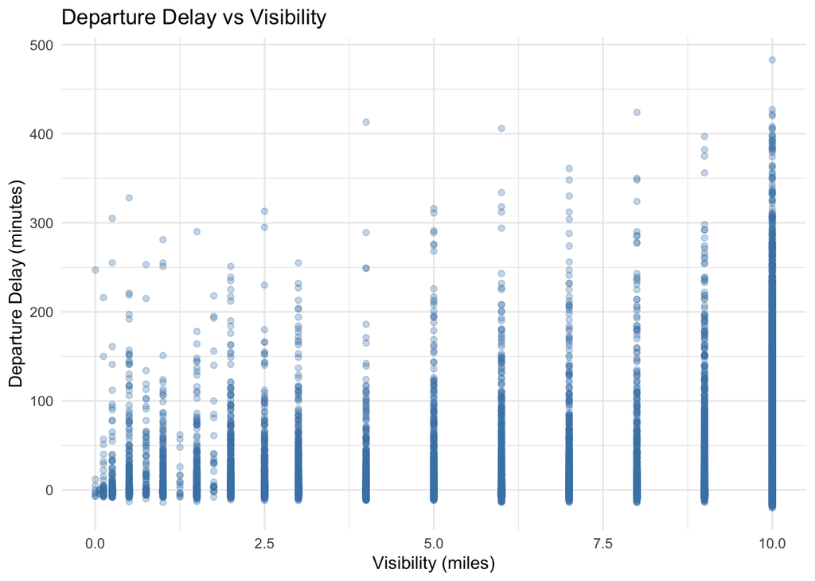

```r
ggplot(flights_weather, aes(x = visib, y = dep_delay)) +
  geom_point(alpha = 0.3, color = "steelblue") +
  labs(
    title = "Departure Delay vs Visibility",
    x = "Visibility (miles)",
    y = "Departure Delay (minutes)"
  ) +
  theme_minimal()
```

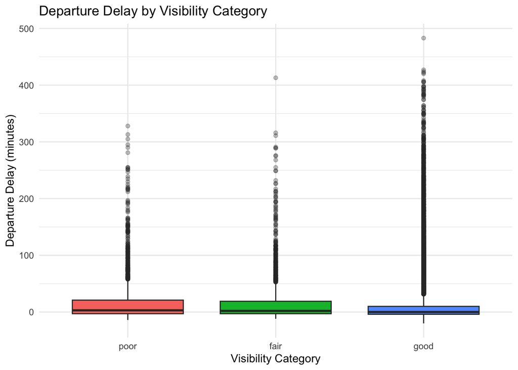

```r
ggplot(flights_weather, aes(x = visib_cat, y = dep_delay, fill = visib_cat)) +
  geom_boxplot(outlier.alpha = 0.3) +
  labs(
    title = "Departure Delay by Visibility Category",
    x = "Visibility Category",
    y = "Departure Delay (minutes)"
  ) +
  theme_minimal() +
  theme(legend.position = "none")
```

######## Q1: Do flights departing in poor visibilty tends to get delayed longer than flights departing in good visibility?  
H~0: $\mu$~P - $\mu$~G = 0  
H~A: $\mu$~P - $\mu$~G $\ge$ 0

```r
poor = flights_weather$dep_delay[flights_weather$visib_cat == 'poor']
good = flights_weather$dep_delay[flights_weather$visib_cat == 'good']

Time <- c(poor, good)

# Observed difference in means
observed <- mean(poor) - mean(good)
observed
```

```
## [1] 7.287139
```

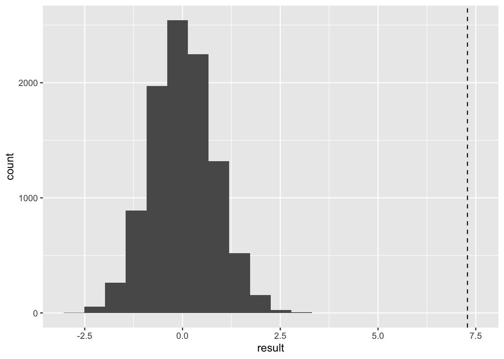

```r
# Get the sample sizes
n1 <- length(poor)
n_total <- length(Time)

# Permutation Test
N <- 10^4 - 1 # number of times to repeat this process
result <- numeric(N) # space to save the random differences

for (i in 1:N) {
  index <- sample(n_total, size = n1, replace = FALSE)
  result[i] <- mean(Time[index]) - mean(Time[-index])
}

# Plot histogram
ggplot() + geom_histogram(aes(result), bins = 20) +
geom_vline(xintercept = observed, linetype = "dashed")
```

```r
# P-value
p_value = (sum(result >= observed) + 1)/(N + 1)
p_value
```

```
## [1] 1e-04
```

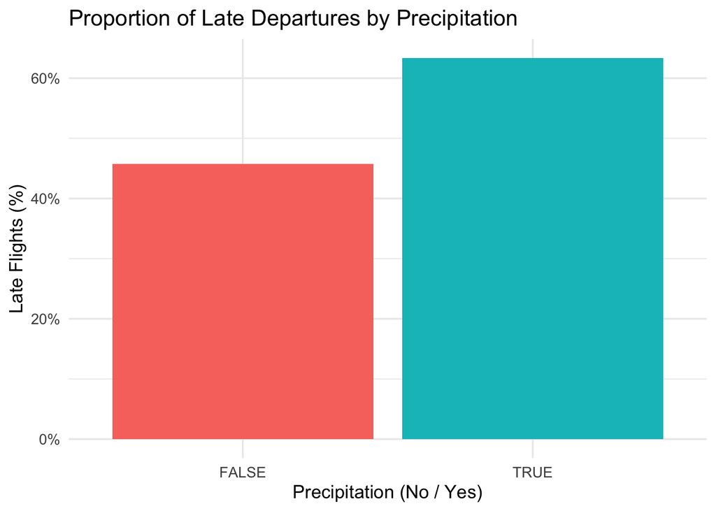

Proportion of Late Flights by Precipitation Condition

```r
# Calculate the proportion of late flights under precipitation vs no precipitation
late_by_precip <- flights_weather %>%
  group_by(precip_binary) %>%
  summarise(late_rate = mean(late, na.rm = TRUE), .groups = "drop")

# Bar plot showing the share of late departures by precipitation
ggplot(late_by_precip, aes(x = precip_binary, y = late_rate, fill = precip_binary)) +
  geom_col(show.legend = FALSE) +
  scale_y_continuous(labels = scales::percent_format()) +
  labs(
    title = "Proportion of Late Departures by Precipitation",
    x = "Precipitation (No / Yes)",
    y = "Late Flights (%)"
  ) +
  theme_minimal(base_size = 13)
```

```r
late_by_precip
```

```
## # A tibble: 2 × 2
##   precip_binary late_rate
##   <lgl>             <dbl>
## 1 FALSE             0.457
## 2 TRUE              0.634
```

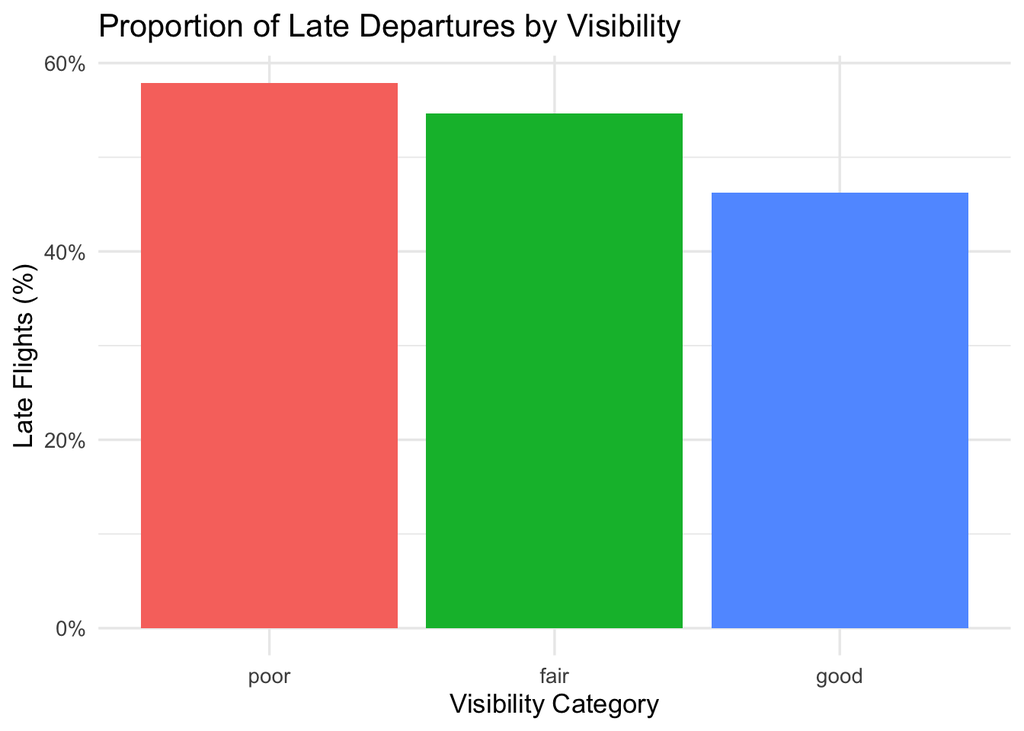

Proportion of Late Flights by Visibility Category

```r
# Calculate the proportion of late flights by visibility category
late_by_visib <- flights_weather %>%
  group_by(visib_cat) %>%
  summarise(late_rate = mean(late, na.rm = TRUE), .groups = "drop")

# Bar plot showing the share of late departures by visibility
ggplot(late_by_visib, aes(x = visib_cat, y = late_rate, fill = visib_cat)) +
  geom_col(show.legend = FALSE) +
  scale_y_continuous(labels = scales::percent_format()) +
  labs(
    title = "Proportion of Late Departures by Visibility",
    x = "Visibility Category",
    y = "Late Flights (%)"
  ) +
  theme_minimal(base_size = 13)
```

```r
late_by_visib
```

```
## # A tibble: 3 × 2
##   visib_cat late_rate
##   <fct>         <dbl>
## 1 poor          0.579
## 2 fair          0.547
## 3 good          0.462
```

The bars represent the fraction of flights that left late within each visibility category. Each bar answers a separate question: Out of all flights that day with this visibility, what share were late?